# 防跌倒扶手调研数据聚类分析

分层聚类方法

## 一、数据加载与检查

### 1.1 加载数据集

加载预处理后的子女和老年人数据集，确保数据文件存在且路径正确。

## 二、子女群体聚类分析

### 2.1 变量筛选与预处理

选择子女群体的相关变量，包括基础信息、需求侧和核心潜变量，确保数据类型正确。

### 2.2 变量标准化

对子女群体的所有变量进行标准化处理，确保不同变量的量纲一致，提高聚类效果。

### 2.3 执行分层聚类

计算距离矩阵并使用Ward方法执行分层聚类，为后续确定最佳聚类数做准备。

### 2.4 确定最佳聚类数并提取标签

使用轮廓系数法确定最佳聚类数k，通过计算不同k值的轮廓系数并选择最大值对应的k，然后提取聚类标签。

```
子女群体最佳聚类数k： 2
```

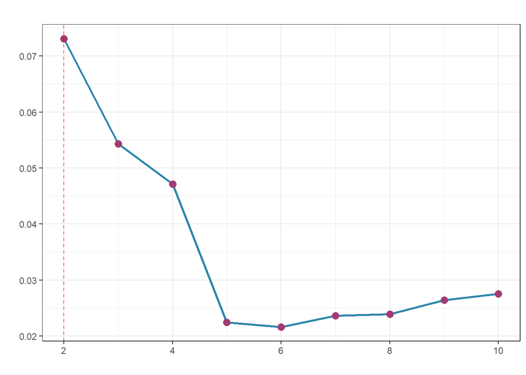

### 2.5 聚类结果分析

分析子女群体的聚类结果，生成特征剖面表格，展示不同聚类的特征差异。

子女群体聚类特征剖面

分层聚类方法

| 特征 | 1 | 2 |
| --- | --- | --- |
| 样本量 | 190.00 | 208.00 |
| 问卷总分均值 | 74.72 | 92.00 |
| 女性占比 | 0.49 | 0.46 |
| 年龄均值 | 2.48 | 2.51 |
| 与老人同住率 | 0.37 | 0.23 |
| 老人年龄均值 | 2.47 | 2.85 |
| 老人失能程度均值 | 1.66 | 1.95 |
| 核心城区占比 | 0.50 | 0.52 |
| 装过扶手率 | 0.39 | 0.38 |
| 可接受价格均值 | 2.78 | 2.66 |
| 卫生间安装偏好率 | 0.90 | 0.90 |
| 床边安装偏好率 | 0.37 | 0.45 |
| 楼道安装偏好率 | 0.79 | 0.77 |
| 阳台安装偏好率 | 0.51 | 0.48 |
| 其他安装偏好率 | 0.13 | 0.20 |
| 基础不锈钢款偏好率 | 0.23 | 0.16 |
| 可折叠款偏好率 | 0.18 | 0.26 |
| 防滑款偏好率 | 0.47 | 0.30 |
| 智能预警款偏好率 | 0.06 | 0.14 |
| 其他类型偏好率 | 0.06 | 0.13 |
| 免费安装期望率 | 0.80 | 0.85 |
| 二十四小时售后期望率 | 0.39 | 0.44 |
| 定期维护期望率 | 0.65 | 0.74 |
| 上门教学期望率 | 0.53 | 0.56 |
| 其他服务期望率 | 0.17 | 0.19 |
| 照护价值均值 | 3.24 | 3.97 |
| 代际责任均值 | 3.37 | 4.23 |
| 决策便利均值 | 3.02 | 3.91 |
| 资源投入均值 | 3.26 | 4.08 |
| 认知偏差均值 | 3.39 | 3.67 |
| 购买意愿均值 | 3.19 | 4.19 |

## 三、老年人群体聚类分析

### 3.1 变量筛选与预处理

选择老年人群体的相关变量，包括基础信息、需求侧和核心潜变量，确保数据类型正确。

### 3.2 变量标准化

对老年人群体的所有变量进行标准化处理，确保不同变量的量纲一致，提高聚类效果。

### 3.3 执行分层聚类

计算距离矩阵并使用Ward方法执行分层聚类，为后续确定最佳聚类数做准备。

### 3.4 确定最佳聚类数并提取标签

使用轮廓系数法确定最佳聚类数k，通过计算不同k值的轮廓系数并选择最大值对应的k，然后提取聚类标签。

```
老年人群体最佳聚类数k： 2
```

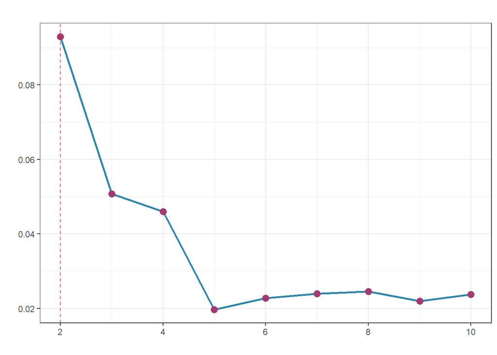

### 3.5 聚类结果分析

分析老年人群体的聚类结果，生成特征剖面表格，展示不同聚类的特征差异。

老年人群体聚类特征剖面

分层聚类方法

| 特征 | 1 | 2 |
| --- | --- | --- |
| 样本量 | 170.00 | 549.00 |
| 问卷总分均值 | 55.52 | 72.10 |
| 女性占比 | 0.58 | 0.64 |
| 年龄均值 | 2.23 | 2.11 |
| 健康状况均值 | 1.55 | 1.55 |
| 核心城区占比 | 0.63 | 0.61 |
| 居家独居率 | 0.59 | 0.54 |
| 居家与子女同住率 | 0.29 | 0.34 |
| 居家跌倒经历率 | 0.52 | 0.58 |
| 已装扶手率 | 0.32 | 0.29 |
| 可接受价格均值 | 2.54 | 2.17 |
| 卫生间安装偏好率 | 0.89 | 0.90 |
| 床边安装偏好率 | 0.39 | 0.40 |
| 楼道安装偏好率 | 0.76 | 0.80 |
| 阳台安装偏好率 | 0.45 | 0.54 |
| 其他安装偏好率 | 0.24 | 0.22 |
| 基础不锈钢款偏好率 | 0.11 | 0.21 |
| 可折叠款偏好率 | 0.45 | 0.18 |
| 防滑款偏好率 | 0.29 | 0.37 |
| 智能预警款偏好率 | 0.12 | 0.11 |
| 其他类型偏好率 | 0.03 | 0.13 |
| 提高补贴力度期望率 | 0.61 | 0.63 |
| 简化申请流程期望率 | 0.56 | 0.52 |
| 差异化补贴期望率 | 0.39 | 0.43 |
| 社区代办申请期望率 | 0.25 | 0.32 |
| 其他补贴期望率 | 0.12 | 0.13 |
| 风险收益均值 | 3.02 | 4.07 |
| 社会支持均值 | 2.95 | 3.81 |
| 政策适配均值 | 2.96 | 3.67 |
| 生活依赖均值 | 2.86 | 3.53 |
| 使用意愿均值 | 2.78 | 3.93 |

### 4. 导出聚类结果

将聚类标签导出为CSV文件，方便后续分析和使用。

### 5. 聚类结果可视化

可视化分层聚类树状图、聚类结果散点图和轮廓系数，直观展示聚类效果。

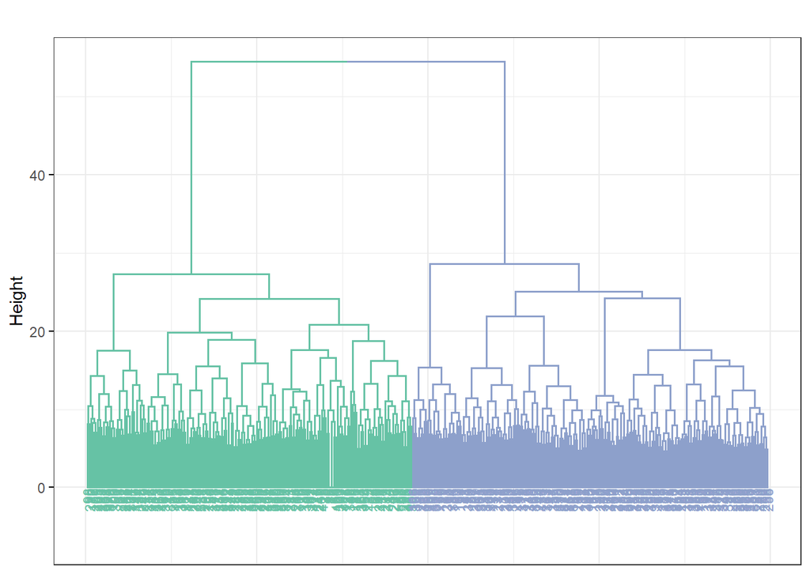

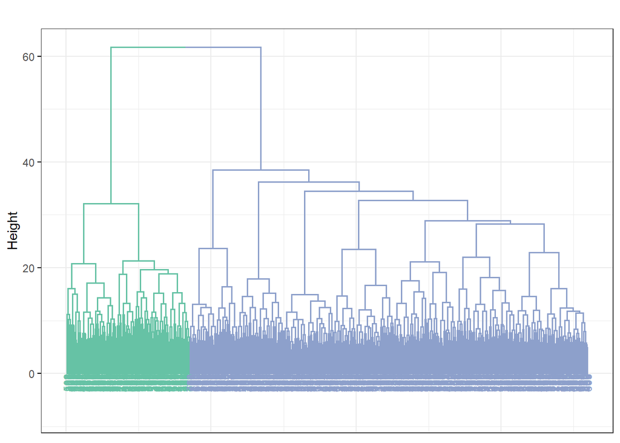

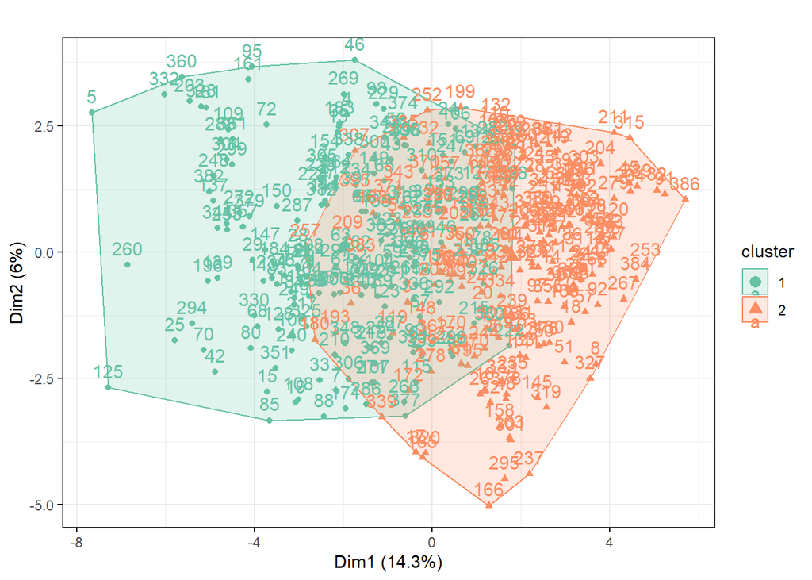

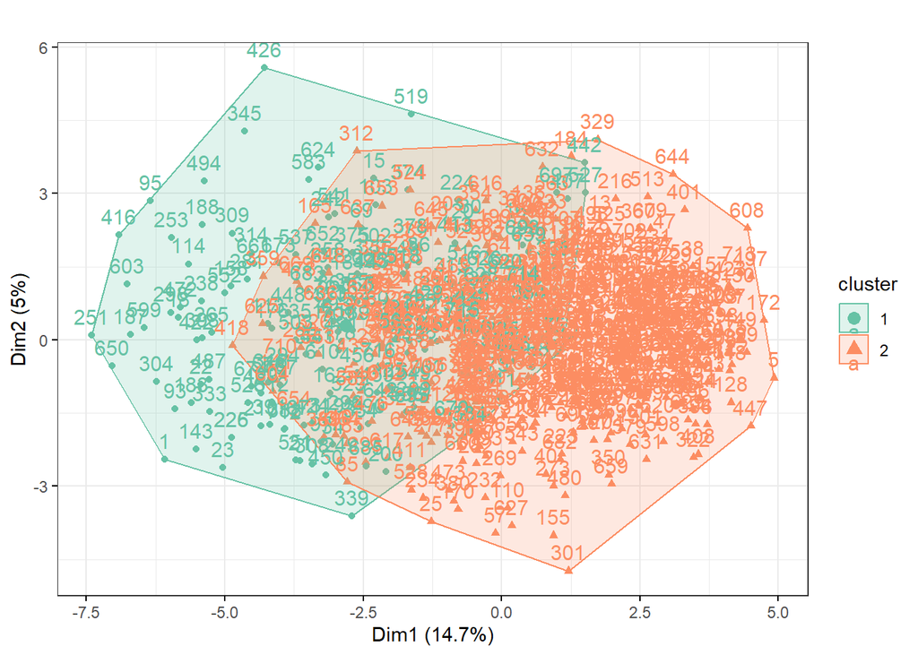

```
  cluster size ave.sil.width
1       1  170          0.03
2       2  549          0.11
```

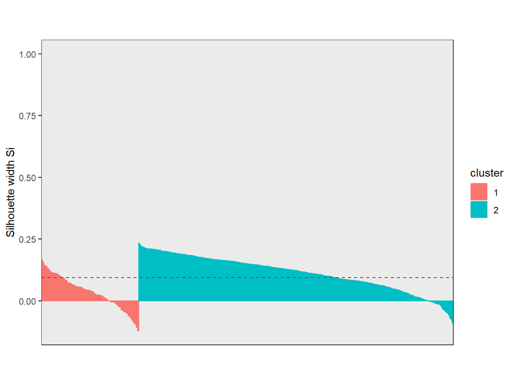

```
  cluster size ave.sil.width
1       1  190          0.03
2       2  208          0.11
```

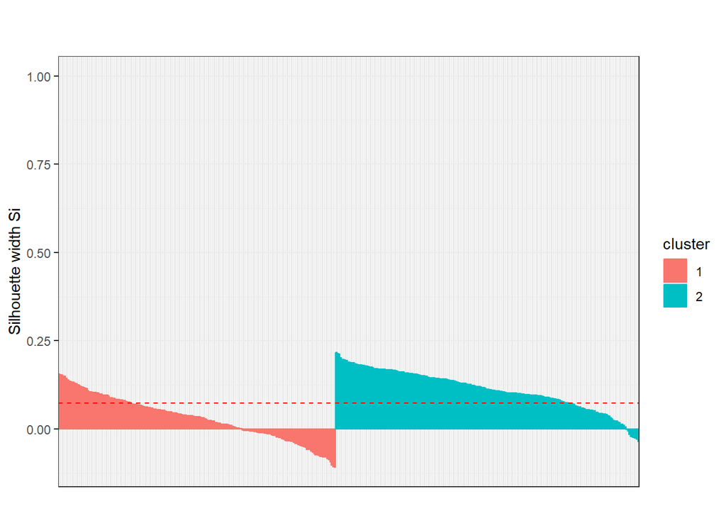